# Risk Factor Analysis

## Outcome Variable

**Outcome Variable:** ever_co

## Predictor Variables

**Intervention Variable:** predfeed3

**Adjustment Set:**

unadjusted

## Stratifying Variables

The analysis was stratified on these variable(s):

- agecat
- studyid
- country

## Data Summary

| agecat | studyid | country | predfeed3 | ever_co | n_cell | n | outcome_variable |
| --- | --- | --- | --- | --- | --- | --- | --- |
| 0-24 months | ki0047075b-MAL-ED | BANGLADESH | 1 | 0 | 167 | 244 | ever_co |
| 0-24 months | ki0047075b-MAL-ED | BANGLADESH | 1 | 1 | 33 | 244 | ever_co |
| 0-24 months | ki0047075b-MAL-ED | BANGLADESH | 0 | 0 | 39 | 244 | ever_co |
| 0-24 months | ki0047075b-MAL-ED | BANGLADESH | 0 | 1 | 5 | 244 | ever_co |
| 0-24 months | ki0047075b-MAL-ED | BRAZIL | 1 | 0 | 95 | 202 | ever_co |
| 0-24 months | ki0047075b-MAL-ED | BRAZIL | 1 | 1 | 3 | 202 | ever_co |
| 0-24 months | ki0047075b-MAL-ED | BRAZIL | 0 | 0 | 104 | 202 | ever_co |
| 0-24 months | ki0047075b-MAL-ED | BRAZIL | 0 | 1 | 0 | 202 | ever_co |
| 0-24 months | ki0047075b-MAL-ED | INDIA | 1 | 0 | 117 | 216 | ever_co |
| 0-24 months | ki0047075b-MAL-ED | INDIA | 1 | 1 | 34 | 216 | ever_co |
| 0-24 months | ki0047075b-MAL-ED | INDIA | 0 | 0 | 50 | 216 | ever_co |
| 0-24 months | ki0047075b-MAL-ED | INDIA | 0 | 1 | 15 | 216 | ever_co |
| 0-24 months | ki0047075b-MAL-ED | NEPAL | 1 | 0 | 100 | 228 | ever_co |
| 0-24 months | ki0047075b-MAL-ED | NEPAL | 1 | 1 | 14 | 228 | ever_co |
| 0-24 months | ki0047075b-MAL-ED | NEPAL | 0 | 0 | 107 | 228 | ever_co |
| 0-24 months | ki0047075b-MAL-ED | NEPAL | 0 | 1 | 7 | 228 | ever_co |
| 0-24 months | ki0047075b-MAL-ED | PERU | 1 | 0 | 184 | 287 | ever_co |
| 0-24 months | ki0047075b-MAL-ED | PERU | 1 | 1 | 4 | 287 | ever_co |
| 0-24 months | ki0047075b-MAL-ED | PERU | 0 | 0 | 92 | 287 | ever_co |
| 0-24 months | ki0047075b-MAL-ED | PERU | 0 | 1 | 7 | 287 | ever_co |
| 0-24 months | ki0047075b-MAL-ED | SOUTH AFRICA | 1 | 0 | 68 | 269 | ever_co |
| 0-24 months | ki0047075b-MAL-ED | SOUTH AFRICA | 1 | 1 | 3 | 269 | ever_co |
| 0-24 months | ki0047075b-MAL-ED | SOUTH AFRICA | 0 | 0 | 180 | 269 | ever_co |
| 0-24 months | ki0047075b-MAL-ED | SOUTH AFRICA | 0 | 1 | 18 | 269 | ever_co |
| 0-24 months | ki0047075b-MAL-ED | TANZANIA, UNITED REPUBLIC OF | 1 | 0 | 63 | 219 | ever_co |
| 0-24 months | ki0047075b-MAL-ED | TANZANIA, UNITED REPUBLIC OF | 1 | 1 | 2 | 219 | ever_co |
| 0-24 months | ki0047075b-MAL-ED | TANZANIA, UNITED REPUBLIC OF | 0 | 0 | 137 | 219 | ever_co |
| 0-24 months | ki0047075b-MAL-ED | TANZANIA, UNITED REPUBLIC OF | 0 | 1 | 17 | 219 | ever_co |
| 0-24 months | ki1000109-EE | PAKISTAN | 1 | 0 | 17 | 39 | ever_co |
| 0-24 months | ki1000109-EE | PAKISTAN | 1 | 1 | 22 | 39 | ever_co |

[output cut: 102 more lines]

The following strata were considered:

- agecat: 0-24 months, studyid: ki0047075b-MAL-ED, country: BANGLADESH
- agecat: 0-24 months, studyid: ki0047075b-MAL-ED, country: BRAZIL
- agecat: 0-24 months, studyid: ki0047075b-MAL-ED, country: INDIA
- agecat: 0-24 months, studyid: ki0047075b-MAL-ED, country: NEPAL
- agecat: 0-24 months, studyid: ki0047075b-MAL-ED, country: PERU
- agecat: 0-24 months, studyid: ki0047075b-MAL-ED, country: SOUTH AFRICA
- agecat: 0-24 months, studyid: ki0047075b-MAL-ED, country: TANZANIA, UNITED REPUBLIC OF
- agecat: 0-24 months, studyid: ki1000109-EE, country: PAKISTAN
- agecat: 0-24 months, studyid: ki1113344-GMS-Nepal, country: NEPAL
- agecat: 0-24 months, studyid: kiGH5241-JiVitA-3, country: BANGLADESH
- agecat: 0-24 months, studyid: kiGH5241-JiVitA-4, country: BANGLADESH
- agecat: 0-6 months, studyid: ki0047075b-MAL-ED, country: BANGLADESH
- agecat: 0-6 months, studyid: ki0047075b-MAL-ED, country: BRAZIL
- agecat: 0-6 months, studyid: ki0047075b-MAL-ED, country: INDIA
- agecat: 0-6 months, studyid: ki0047075b-MAL-ED, country: NEPAL
- agecat: 0-6 months, studyid: ki0047075b-MAL-ED, country: PERU
- agecat: 0-6 months, studyid: ki0047075b-MAL-ED, country: SOUTH AFRICA
- agecat: 0-6 months, studyid: ki0047075b-MAL-ED, country: TANZANIA, UNITED REPUBLIC OF
- agecat: 0-6 months, studyid: ki1000109-EE, country: PAKISTAN
- agecat: 0-6 months, studyid: ki1113344-GMS-Nepal, country: NEPAL
- agecat: 0-6 months, studyid: kiGH5241-JiVitA-3, country: BANGLADESH
- agecat: 0-6 months, studyid: kiGH5241-JiVitA-4, country: BANGLADESH
- agecat: 6-24 months, studyid: ki0047075b-MAL-ED, country: BANGLADESH
- agecat: 6-24 months, studyid: ki0047075b-MAL-ED, country: BRAZIL
- agecat: 6-24 months, studyid: ki0047075b-MAL-ED, country: INDIA
- agecat: 6-24 months, studyid: ki0047075b-MAL-ED, country: NEPAL
- agecat: 6-24 months, studyid: ki0047075b-MAL-ED, country: PERU
- agecat: 6-24 months, studyid: ki0047075b-MAL-ED, country: SOUTH AFRICA
- agecat: 6-24 months, studyid: ki0047075b-MAL-ED, country: TANZANIA, UNITED REPUBLIC OF
- agecat: 6-24 months, studyid: ki1000109-EE, country: PAKISTAN
- agecat: 6-24 months, studyid: ki1113344-GMS-Nepal, country: NEPAL
- agecat: 6-24 months, studyid: kiGH5241-JiVitA-3, country: BANGLADESH
- agecat: 6-24 months, studyid: kiGH5241-JiVitA-4, country: BANGLADESH

### Dropped Strata

Some strata were dropped due to rare outcomes:

- agecat: 0-24 months, studyid: ki0047075b-MAL-ED, country: BRAZIL
- agecat: 0-24 months, studyid: ki0047075b-MAL-ED, country: PERU
- agecat: 0-24 months, studyid: ki0047075b-MAL-ED, country: SOUTH AFRICA
- agecat: 0-24 months, studyid: ki0047075b-MAL-ED, country: TANZANIA, UNITED REPUBLIC OF
- agecat: 0-24 months, studyid: ki1000109-EE, country: PAKISTAN
- agecat: 0-24 months, studyid: kiGH5241-JiVitA-4, country: BANGLADESH
- agecat: 0-6 months, studyid: ki0047075b-MAL-ED, country: BANGLADESH
- agecat: 0-6 months, studyid: ki0047075b-MAL-ED, country: BRAZIL
- agecat: 0-6 months, studyid: ki0047075b-MAL-ED, country: NEPAL
- agecat: 0-6 months, studyid: ki0047075b-MAL-ED, country: PERU
- agecat: 0-6 months, studyid: ki0047075b-MAL-ED, country: SOUTH AFRICA
- agecat: 0-6 months, studyid: ki0047075b-MAL-ED, country: TANZANIA, UNITED REPUBLIC OF
- agecat: 0-6 months, studyid: ki1000109-EE, country: PAKISTAN
- agecat: 0-6 months, studyid: kiGH5241-JiVitA-4, country: BANGLADESH
- agecat: 6-24 months, studyid: ki0047075b-MAL-ED, country: BANGLADESH
- agecat: 6-24 months, studyid: ki0047075b-MAL-ED, country: BRAZIL
- agecat: 6-24 months, studyid: ki0047075b-MAL-ED, country: NEPAL
- agecat: 6-24 months, studyid: ki0047075b-MAL-ED, country: PERU
- agecat: 6-24 months, studyid: ki0047075b-MAL-ED, country: SOUTH AFRICA
- agecat: 6-24 months, studyid: ki0047075b-MAL-ED, country: TANZANIA, UNITED REPUBLIC OF
- agecat: 6-24 months, studyid: ki1000109-EE, country: PAKISTAN
- agecat: 6-24 months, studyid: kiGH5241-JiVitA-4, country: BANGLADESH

## Methods Detail

We’re interested in the causal parameters $E[Y_a]$ for all values of $a \in \mathcal{A}$. These parameters represent the mean outcome if, possibly contrary to fact, we intervened to set all units to have $A=a$. Under the randomization and positivity assumptions, these are identified by the statistical parameters $\psi_a=E_W[E_{Y|A,W}(Y|A=a,W)]$. In addition, we’re interested in the mean of $Y$, $E[Y]$ under no intervention (the observed mean). We will estimate these parameters by using SuperLearner to fit the relevant likelihood factors – $E_{Y|A,W}(Y|A=a,W)$ and $p(A=a|W)$, and then updating our likelihood fit using a joint TMLE.

For unadjusted analyses ($W=\{\}$), initial likelihoods were estimated using Lrnr_glm to estimate the simple $E(Y|A)$ and Lrnr_mean to estimate $p(A)$. For adjusted analyses, a small library containing Lrnr_glmnet, Lrnr_xgboost, and Lrnr_mean was used.

Having estimated these parameters, we will then use the delta method to estimate relative risks and attributable risks relative to a prespecified baseline level of $A$.

# Results Detail

## Results Plots

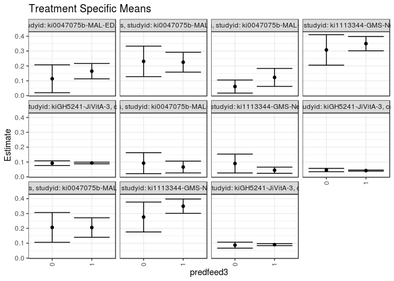

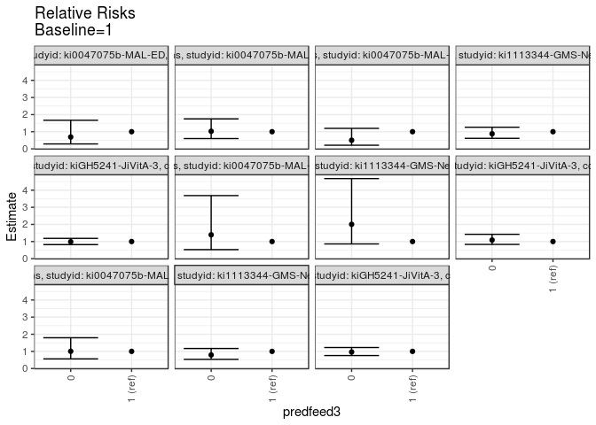

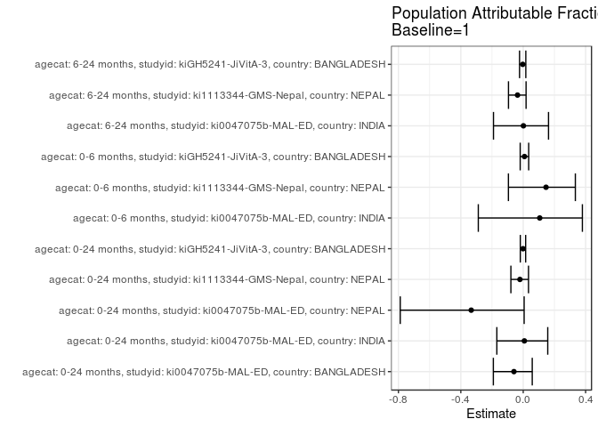

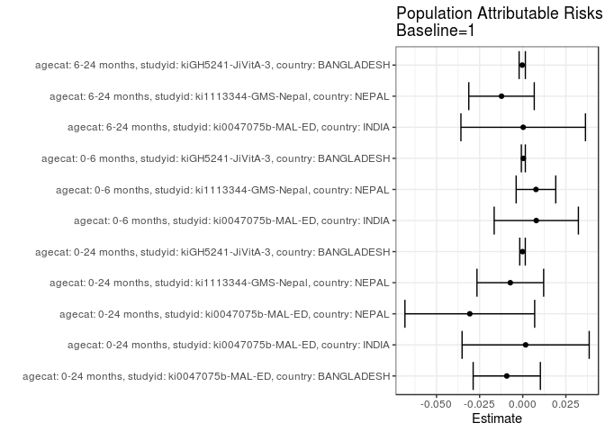

## Results Table

### Parameter: TSM

| agecat | studyid | country | intervention_level | baseline_level | estimate | ci_lower | ci_upper |
| --- | --- | --- | --- | --- | --- | --- | --- |
| 0-24 months | ki0047075b-MAL-ED | BANGLADESH | 1 | NA | 0.1650000 | 0.1134522 | 0.2165478 |
| 0-24 months | ki0047075b-MAL-ED | BANGLADESH | 0 | NA | 0.1136364 | 0.0196688 | 0.2076040 |
| 0-24 months | ki0047075b-MAL-ED | INDIA | 1 | NA | 0.2251656 | 0.1583892 | 0.2919419 |
| 0-24 months | ki0047075b-MAL-ED | INDIA | 0 | NA | 0.2307692 | 0.1281057 | 0.3334328 |
| 0-24 months | ki0047075b-MAL-ED | NEPAL | 1 | NA | 0.1228070 | 0.0624248 | 0.1831893 |
| 0-24 months | ki0047075b-MAL-ED | NEPAL | 0 | NA | 0.0614035 | 0.0172377 | 0.1055693 |
| 0-24 months | ki1113344-GMS-Nepal | NEPAL | 1 | NA | 0.3500000 | 0.3019911 | 0.3980089 |
| 0-24 months | ki1113344-GMS-Nepal | NEPAL | 0 | NA | 0.3076923 | 0.2051547 | 0.4102299 |
| 0-24 months | kiGH5241-JiVitA-3 | BANGLADESH | 1 | NA | 0.0935772 | 0.0882404 | 0.0989140 |
| 0-24 months | kiGH5241-JiVitA-3 | BANGLADESH | 0 | NA | 0.0922535 | 0.0765012 | 0.1080058 |
| 0-6 months | ki0047075b-MAL-ED | INDIA | 1 | NA | 0.0662252 | 0.0264694 | 0.1059809 |
| 0-6 months | ki0047075b-MAL-ED | INDIA | 0 | NA | 0.0923077 | 0.0217755 | 0.1628399 |
| 0-6 months | ki1113344-GMS-Nepal | NEPAL | 1 | NA | 0.0447368 | 0.0239291 | 0.0655446 |
| 0-6 months | ki1113344-GMS-Nepal | NEPAL | 0 | NA | 0.0897436 | 0.0262457 | 0.1532414 |
| 0-6 months | kiGH5241-JiVitA-3 | BANGLADESH | 1 | NA | 0.0421807 | 0.0384591 | 0.0459023 |
| 0-6 months | kiGH5241-JiVitA-3 | BANGLADESH | 0 | NA | 0.0458716 | 0.0344954 | 0.0572477 |
| 6-24 months | ki0047075b-MAL-ED | INDIA | 1 | NA | 0.2054795 | 0.1397818 | 0.2711771 |
| 6-24 months | ki0047075b-MAL-ED | INDIA | 0 | NA | 0.2063492 | 0.1061797 | 0.3065187 |
| 6-24 months | ki1113344-GMS-Nepal | NEPAL | 1 | NA | 0.3493333 | 0.3010259 | 0.3976407 |
| 6-24 months | ki1113344-GMS-Nepal | NEPAL | 0 | NA | 0.2763158 | 0.1756688 | 0.3769628 |
| 6-24 months | kiGH5241-JiVitA-3 | BANGLADESH | 1 | NA | 0.0904225 | 0.0839210 | 0.0969240 |
| 6-24 months | kiGH5241-JiVitA-3 | BANGLADESH | 0 | NA | 0.0870617 | 0.0669469 | 0.1071764 |

### Parameter: E(Y)

| agecat | studyid | country | intervention_level | baseline_level | estimate | ci_lower | ci_upper |
| --- | --- | --- | --- | --- | --- | --- | --- |
| 0-24 months | ki0047075b-MAL-ED | BANGLADESH | NA | NA | 0.1557377 | 0.1101466 | 0.2013289 |
| 0-24 months | ki0047075b-MAL-ED | INDIA | NA | NA | 0.2268519 | 0.1708720 | 0.2828317 |
| 0-24 months | ki0047075b-MAL-ED | NEPAL | NA | NA | 0.0921053 | 0.0544873 | 0.1297232 |
| 0-24 months | ki1113344-GMS-Nepal | NEPAL | NA | NA | 0.3427948 | 0.2992779 | 0.3863116 |
| 0-24 months | kiGH5241-JiVitA-3 | BANGLADESH | NA | NA | 0.0934517 | 0.0884729 | 0.0984306 |
| 0-6 months | ki0047075b-MAL-ED | INDIA | NA | NA | 0.0740741 | 0.0390675 | 0.1090807 |
| 0-6 months | ki1113344-GMS-Nepal | NEPAL | NA | NA | 0.0524017 | 0.0319714 | 0.0728321 |
| 0-6 months | kiGH5241-JiVitA-3 | BANGLADESH | NA | NA | 0.0425304 | 0.0390546 | 0.0460063 |
| 6-24 months | ki0047075b-MAL-ED | INDIA | NA | NA | 0.2057416 | 0.1508055 | 0.2606778 |
| 6-24 months | ki1113344-GMS-Nepal | NEPAL | NA | NA | 0.3370288 | 0.2933549 | 0.3807028 |
| 6-24 months | kiGH5241-JiVitA-3 | BANGLADESH | NA | NA | 0.0901332 | 0.0839189 | 0.0963475 |

### Parameter: RR

| agecat | studyid | country | intervention_level | baseline_level | estimate | ci_lower | ci_upper |
| --- | --- | --- | --- | --- | --- | --- | --- |
| 0-24 months | ki0047075b-MAL-ED | BANGLADESH | 1 | 1 | 1.0000000 | 1.0000000 | 1.000000 |
| 0-24 months | ki0047075b-MAL-ED | BANGLADESH | 0 | 1 | 0.6887052 | 0.2845336 | 1.666991 |
| 0-24 months | ki0047075b-MAL-ED | INDIA | 1 | 1 | 1.0000000 | 1.0000000 | 1.000000 |
| 0-24 months | ki0047075b-MAL-ED | INDIA | 0 | 1 | 1.0248869 | 0.6004467 | 1.749353 |
| 0-24 months | ki0047075b-MAL-ED | NEPAL | 1 | 1 | 1.0000000 | 1.0000000 | 1.000000 |
| 0-24 months | ki0047075b-MAL-ED | NEPAL | 0 | 1 | 0.5000000 | 0.2092107 | 1.194968 |
| 0-24 months | ki1113344-GMS-Nepal | NEPAL | 1 | 1 | 1.0000000 | 1.0000000 | 1.000000 |
| 0-24 months | ki1113344-GMS-Nepal | NEPAL | 0 | 1 | 0.8791209 | 0.6131129 | 1.260540 |
| 0-24 months | kiGH5241-JiVitA-3 | BANGLADESH | 1 | 1 | 1.0000000 | 1.0000000 | 1.000000 |
| 0-24 months | kiGH5241-JiVitA-3 | BANGLADESH | 0 | 1 | 0.9858550 | 0.8210473 | 1.183744 |
| 0-6 months | ki0047075b-MAL-ED | INDIA | 1 | 1 | 1.0000000 | 1.0000000 | 1.000000 |
| 0-6 months | ki0047075b-MAL-ED | INDIA | 0 | 1 | 1.3938462 | 0.5274805 | 3.683183 |
| 0-6 months | ki1113344-GMS-Nepal | NEPAL | 1 | 1 | 1.0000000 | 1.0000000 | 1.000000 |
| 0-6 months | ki1113344-GMS-Nepal | NEPAL | 0 | 1 | 2.0060331 | 0.8602152 | 4.678095 |
| 0-6 months | kiGH5241-JiVitA-3 | BANGLADESH | 1 | 1 | 1.0000000 | 1.0000000 | 1.000000 |
| 0-6 months | kiGH5241-JiVitA-3 | BANGLADESH | 0 | 1 | 1.0875014 | 0.8318596 | 1.421705 |
| 6-24 months | ki0047075b-MAL-ED | INDIA | 1 | 1 | 1.0000000 | 1.0000000 | 1.000000 |
| 6-24 months | ki0047075b-MAL-ED | INDIA | 0 | 1 | 1.0042328 | 0.5615545 | 1.795878 |
| 6-24 months | ki1113344-GMS-Nepal | NEPAL | 1 | 1 | 1.0000000 | 1.0000000 | 1.000000 |
| 6-24 months | ki1113344-GMS-Nepal | NEPAL | 0 | 1 | 0.7909803 | 0.5357462 | 1.167810 |
| 6-24 months | kiGH5241-JiVitA-3 | BANGLADESH | 1 | 1 | 1.0000000 | 1.0000000 | 1.000000 |
| 6-24 months | kiGH5241-JiVitA-3 | BANGLADESH | 0 | 1 | 0.9628319 | 0.7566880 | 1.225135 |

### Parameter: PAR

| agecat | studyid | country | intervention_level | baseline_level | estimate | ci_lower | ci_upper |
| --- | --- | --- | --- | --- | --- | --- | --- |
| 0-24 months | ki0047075b-MAL-ED | BANGLADESH | 1 | NA | -0.0092623 | -0.0287483 | 0.0102237 |
| 0-24 months | ki0047075b-MAL-ED | INDIA | 1 | NA | 0.0016863 | -0.0351697 | 0.0385423 |
| 0-24 months | ki0047075b-MAL-ED | NEPAL | 1 | NA | -0.0307018 | -0.0683197 | 0.0069162 |
| 0-24 months | ki1113344-GMS-Nepal | NEPAL | 1 | NA | -0.0072052 | -0.0265423 | 0.0121319 |
| 0-24 months | kiGH5241-JiVitA-3 | BANGLADESH | 1 | NA | -0.0001255 | -0.0017276 | 0.0014767 |
| 0-6 months | ki0047075b-MAL-ED | INDIA | 1 | NA | 0.0078489 | -0.0165679 | 0.0322658 |
| 0-6 months | ki1113344-GMS-Nepal | NEPAL | 1 | NA | 0.0076649 | -0.0038202 | 0.0191500 |
| 0-6 months | kiGH5241-JiVitA-3 | BANGLADESH | 1 | NA | 0.0003497 | -0.0008049 | 0.0015043 |
| 6-24 months | ki0047075b-MAL-ED | INDIA | 1 | NA | 0.0002622 | -0.0358474 | 0.0363717 |
| 6-24 months | ki1113344-GMS-Nepal | NEPAL | 1 | NA | -0.0123045 | -0.0312861 | 0.0066771 |
| 6-24 months | kiGH5241-JiVitA-3 | BANGLADESH | 1 | NA | -0.0002893 | -0.0021005 | 0.0015220 |

### Parameter: PAF

| agecat | studyid | country | intervention_level | baseline_level | estimate | ci_lower | ci_upper |
| --- | --- | --- | --- | --- | --- | --- | --- |
| 0-24 months | ki0047075b-MAL-ED | BANGLADESH | 1 | NA | -0.0594737 | -0.1914494 | 0.0578832 |
| 0-24 months | ki0047075b-MAL-ED | INDIA | 1 | NA | 0.0074334 | -0.1690815 | 0.1572971 |
| 0-24 months | ki0047075b-MAL-ED | NEPAL | 1 | NA | -0.3333333 | -0.7884039 | 0.0059417 |
| 0-24 months | ki1113344-GMS-Nepal | NEPAL | 1 | NA | -0.0210191 | -0.0790210 | 0.0338649 |
| 0-24 months | kiGH5241-JiVitA-3 | BANGLADESH | 1 | NA | -0.0013426 | -0.0186290 | 0.0156505 |
| 0-6 months | ki0047075b-MAL-ED | INDIA | 1 | NA | 0.1059603 | -0.2879157 | 0.3793794 |
| 0-6 months | ki1113344-GMS-Nepal | NEPAL | 1 | NA | 0.1462719 | -0.0948184 | 0.3342716 |
| 0-6 months | kiGH5241-JiVitA-3 | BANGLADESH | 1 | NA | 0.0082232 | -0.0193456 | 0.0350464 |
| 6-24 months | ki0047075b-MAL-ED | INDIA | 1 | NA | 0.0012743 | -0.1906007 | 0.1622271 |
| 6-24 months | ki1113344-GMS-Nepal | NEPAL | 1 | NA | -0.0365088 | -0.0943988 | 0.0183191 |
| 6-24 months | kiGH5241-JiVitA-3 | BANGLADESH | 1 | NA | -0.0032095 | -0.0235050 | 0.0166836 |